# Learning R with Generative AI in a Metagenomics Data Science Course – Survey Results

Published

May 27, 2026

# Author Information

**Jeffrey L Blanchard**  
ORCID: 0000-0002-7310-9678  
Email: jlb@umass.edu  
University of Massachusetts Amherst  
Amherst, MA  
https://jeffreyblanchard.github.io/lab/

### Overview

These graphs, tables and open responses are from an anonymous Google forms survey that was designed to solicit students’ personal experience on the effectiveness of using generative AI in this course. The input files with the with the raw survey results and the thematic coding of the open responses can be found in in the course [GitHub repository](https://github.com/jeffreyblanchard/PathoGen2025/tree/main/survey). These results are generated from this csv file and the underlying R code can also be found in the above GitHub repo and are rendered on this [survey page](https://jeffreyblanchard.github.io/PathoGen2025/survey.html). The R code for producing many of these graphs was developed interactively using the UMass Amherst GenAI platform with OpenAI GPT-5-mini or Anthropic Claude 4.6 Opus

### Figure S1. Prior Coding Experience

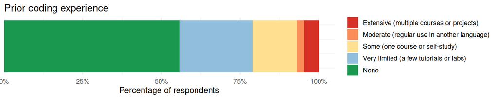

### Figure S2. Frequency of AI Use

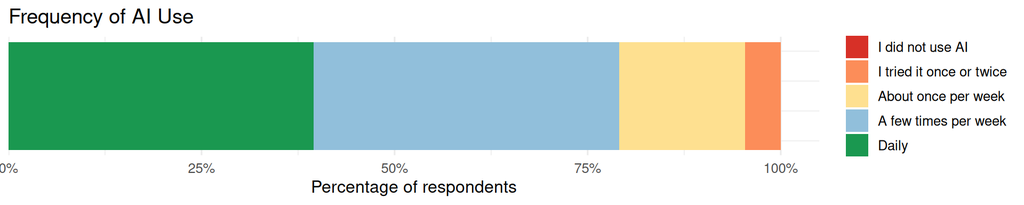

### Figure S3. How much time did using AI save me?

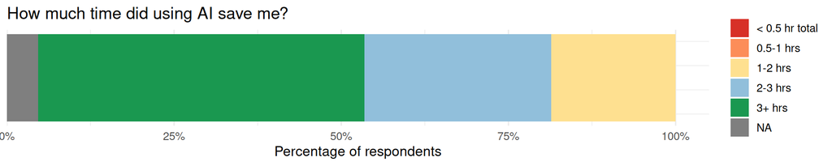

### Figure S4. Frequency of incorrect AI output

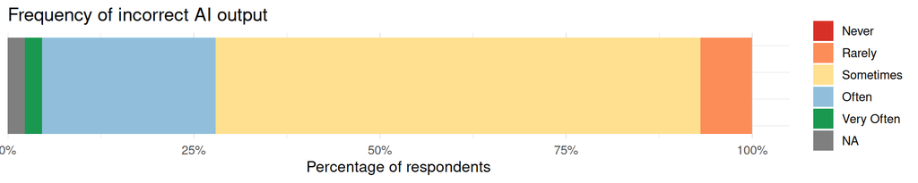

### Figure S5. Did you become more engaged or interactive in solving problems using AI?

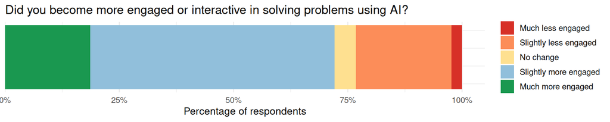

### Figure S6. Confidence change in programming in R

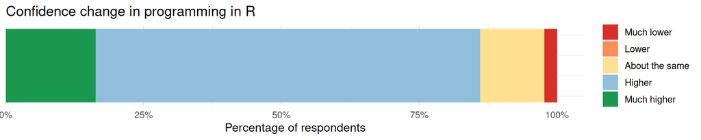

### Figure S7. Clarity of instructions on AI use

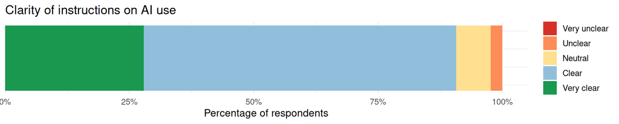

### Figure S8. Combined likert graph of multiple choice grids

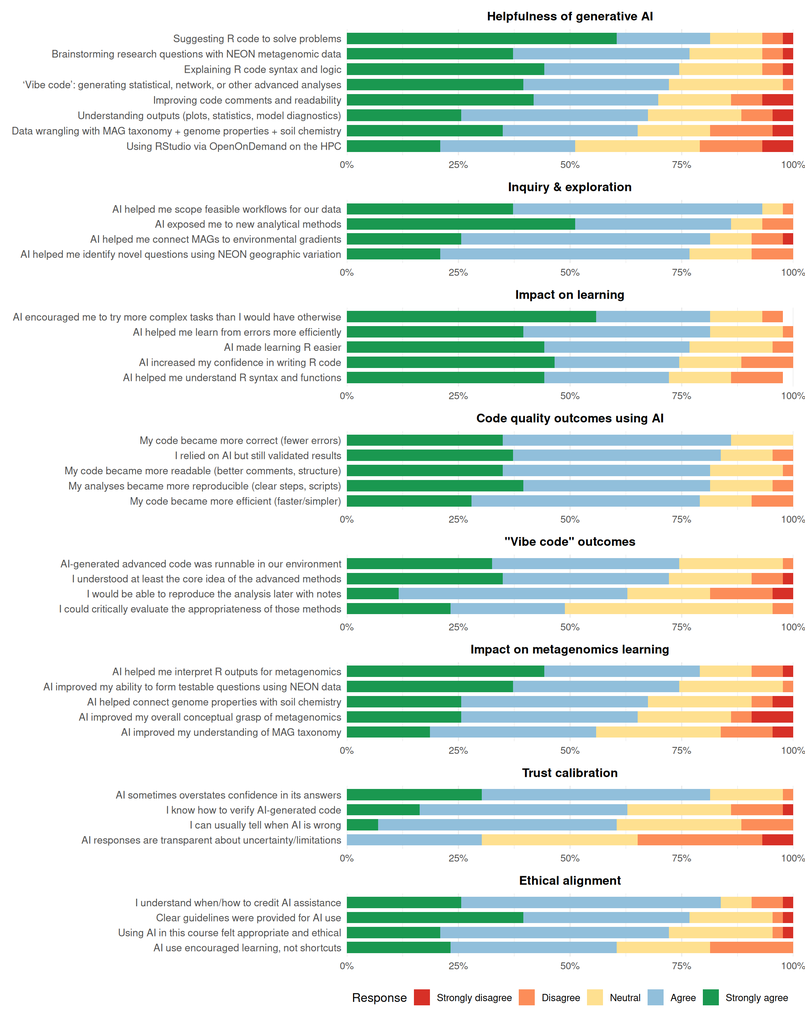

### Figure S9. When AI was wrong, I typically…

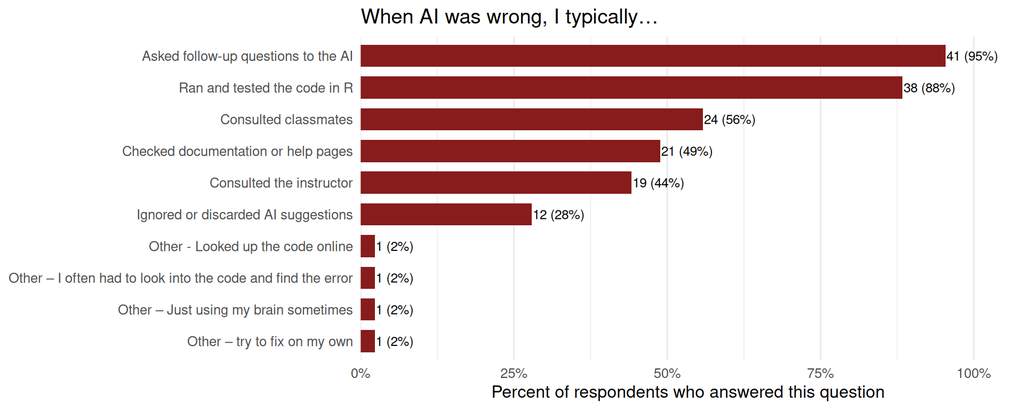

### Figure S10. Common issues encountered

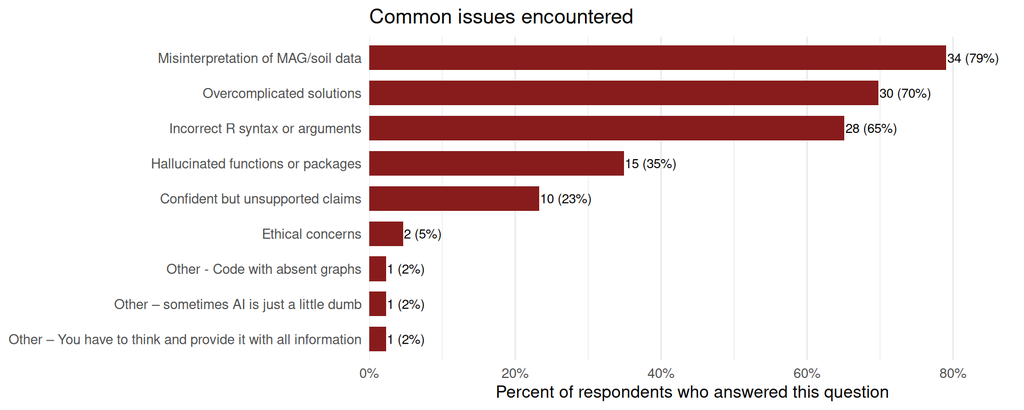

### Figure S11. Where more support would help

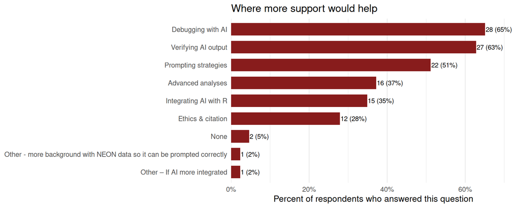

### Table S1 - Overall effectiveness / Likelihood to recommend AI

| column | mean | sd | n |
| --- | --- | --- | --- |
| Likelihood to recommend AI use in similar courses | 7.86 | 1.98 | 43 |
| Overall effectiveness of AI in this course | 8.60 | 1.22 | 43 |

### Table S2. Examples of helpful AI responses - Open response

```
It telling me how to create statistical analysis formulas to compare data
points, and how to map graphs

Sometime when I didn't know how to attack a problem it would take me through the
steps I needed to do before I wrote a code to answer the question like cleaning
up or merging data

Before we learned the definitions of regex patterns and I tried to ask AI
to create patterns for effective character finding, I used AI to give an
explanation of the reasoning and meaning of the regex patterns it generated
Even before we formally learned the skill, AI helped me think of advanced regex
patterns

Writing code blocks utilizing functions/libraries I hadn't used before

clarity on homework / studying

Giving me different types of analysis I could do to see spatial autocorrelation
for the MAG and metadata dataset

Making sense of the outputs generated by the code Or clarifying what table
categories that have slightly different names from the instructions are most
likely to be what the instructions are trying to direct you to

It really helped a lot during the lab exercises and it also explains it too

When working with the NEON Mags dataset, the AI gave very good suggestions on
how to go about formatting my data and what errors were preventing my code from
running

NA

A lot of the time I asked AI to help explain certain coding functions or I would
ask them why I am getting the error message I am getting when rendering my lab
and that's helped me learn from why I can't write the code in certain ways So
AI has definitely helped me improve my coding syntax so that less errors come up
when I render my labs

AI was very good at telling me what an error message meant, provided that I gave
them the exact error message R was giving me AI would often explain what the
```

[output cut: 123 more lines]

```
would need to expand on this question My problem is that I’m not creative
(maybe not curious enough?) with my questions This is why using AI to jumpstart
brainstorming is especially helpful, especially because it can quickly provide
background information that might spark my curiosity

What's wrong here? - “You are getting this error because joinID does not exist
in the right table Check colnames() and rename before left_join()”

AI fixing errors in my code

Providing multiple approaches

Most useful with chunks of code for statistical analysis and plots readibility

NA
```

### Table S3. Examples of unhelpful or incorrect AI responses - Open response

```
When it would tell me to use formulas that needed only numerical values but I
had N/A in my values It would tell me to use random names or column types that
didn't exist

Sometimes if I had an error it would keep giving me incorrect codes to the point
where nothing worked and I did'nt know how to tell fix this issue

When reading the soil mags + soil chem csv file to create Vibe code, AI would
either reveal that the file is too big to be read or it would pretend to read
it Either way, it would generate code that assumed variables and column names,
which were often incorrect

Many AI responses generate code that contain errors

using AI for therapy

The codes it would give me would have a lot of errors, but this was fine because
you learn a lot by seeing where those mistakes are and how to fix them yourself

When you're trying to fix a path directory error or use code it's giving you and
you don't realize the proper names of the files are wrong and thats the secret
reason why nothing is working

It takes a couple of tries for copilot to understand what is being asked which
can be frustrating

When it came to working with GitHub or other external R coding, AI was not
able to give very helpful tips and was just reiterating the same response in
different wording

NA

Sometimes when prompting AI with my questions, I've learned that you have to
craft the question very specifically in order for them to give generally what
you're looking for The times that I have found AI giving unhelpful responses is
when I don't prompt it correctly and sometimes it will give me an answer/code
that uses a library or code function that we have not learned or not part of the
lesson we are working on

When combining data frames I found that using AI wasn't as helpful as just
```

[output cut: 108 more lines]

```
to spend time to learn about matrices I think the only issue with AI feedback
here is that my code is nuanced to the data I’m working with and AI doesn’t
get to have the full picture I admit I could have been less lazy here and try
troubleshooting it myself!

“Here is an answer” with facts that are wrong or made up (hallucinating)

AI going in the wrong direction about my code

Misunderstanding the prompt, hallucinations

Hardest to solve problems If something did not work or wrong answer, needed to
figure it out mostly on my own, AI hardly could fix it

NA
```

### Table S4. Suggested changes for future offering - Open response

```
More help on github pushing and just using github as a whole

I think AI helped my learning expirence I would just add more to debugging and
varifying AI like how to maybe do a monday class on this instead of a lab

I definitely think that lab reports should require students to report the prompt
that was used to generate any code they used, preceding an exercise I think this
is important data for this class and can be used to think of effective prompting
strategies One idea I had, is to use Monday discussions to do either class-wide
or team/table debriefing in which we talk about what sort of code we are getting
from AI I think a collaborative aspect in this class would be helpful for
keeping students on track together

The problems often felt formatted/designed in a way where AI use could easily
solve them without requiring critical thinking from the student I think problems
that focus more on having students determine what steps (or generated code
chunks) would need to be taken could help the course encourage greater learning

NA

Covering more on ethics and AI use

NA

I think because there is a Monday and Wednesday portion, The Monday portion
should be spent explaining what the lab on Wednesday will be I found myself
using AI a lot for things that I felt could’ve been discussed in class

Some assignments that focus more on the content of the course (ie assignments
that teach about NEON and soil chemistry/make up and how the research is
advancing) and where AI is not used

NA

I think when starting with AI sometimes it's easy to just copy and paste the
question we're asked, but I think it would be helpful to start off with examples
of how we can prompt AI to guide us in answering our problems

NA

```

[output cut: 122 more lines]

```
is up to how disciplined they are able to be when they have powerful resources
like AI

N/A

NA

NA

I think it's like a calculator, I would not use it for anything else It works
less well than google for research, but it works as expected when given complex
prompts You may need to amen/check the equation yourself for sure, but it will
be able to give you a decent starting point/do the easy stuff faster than you

NA
```

### Table S5. Final comments and suggestions - Open response

```
Ai really did help and I feel like it is needed for advanced code based on the
level of most students in this class, it just made it so coding felt robotic and
I learned a little less

I liked being able to use AI but I wish I knew what to do if I fall down a
rabbit hole of incorrect codes with CoPilot

Your suggestions of introducing the "Vibe" code mini labs earlier in the
semester is interesting to me I think it would be helpful in one way, as it sort
of shows students our final goals for this class and can give ideas on what AI
can be used to achieve On the other hand, it might introduce advanced code too
quickly and can make students feel lost or left behind

NA

NA

Very well structured, I learned a lot

NA

NA

NA

NA

I think the integration of AI is helpful in beginner courses as sometimes AI
has a good way to "dumb" things down almost to explain why the code produces the
output that it does Sometimes having a conversation with AI helps the learner
understand a lot more than just reading the textbook because sometimes we need
more examples than just the ones provided to see what the concept is trying to
show us

NA

helped me feel like i could confidently code if asked to

Loved this class, Dr Blanchard was super helpful and made coding seem fun even
though I have never liked to code Love AI, makes sense for coding courses do not
```

[output cut: 158 more lines]

```
I suspected it sounded too good to be true (that's probably because by nature,
I also have a tendency to say things with a lot of confidence even if they are
not true—simply because I believe them) If someone came to me with the total
confidence that there are three types of T cells, I would know better and tell
them "that's not true" If they told me "a new type of IgG was discovered in
a paper by Matt et al," I'd have a tendency to say "yes? Can you show me?" If
I was told "Did you know there are over 300 types of turtles?" I may have a
small doubt, but usually say "oh nice!" and accept it as a doubtful, but actual
fact (and mess up and repeat it with total confidence to other people as a
truth) Asking any question to AI comes with the understanding that it is only a
computer and just does math But even if it could think and was human, wouldn't
we also double-check their statement and thoughts? Or correct them, or ask for
proofs?

NA
```

### Analysis of open responses using common themes - Overview

All open-text responses from four survey sections (Above Tables S2-S5) were systematically reviewed and coded thematically. A coding scheme was developed inductively from the response data and applied consistently across all substantive responses using Anthropic Claude 4.6 Sonnet. Responses marked NA, N/A, or providing only brief affirmations (e.g., “Thank you”) were excluded as non-substantive. Multiple codes were permitted per response when a single response addressed more than one theme. The denominator for percentage calculations reflects the number of substantive responses in each section. JLB manually reviewed and edited the assignment of comments to responses themes.

### Figure S12. Analysis of open responses using common themes

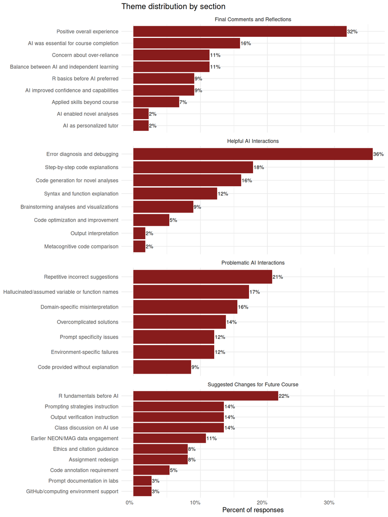